# POL 211 Discussion

Author

Max Welch

Published

January 1, 2026

← All courses

This material borrows heavily from an earlier version by Yu-Shiuan (Lily) Huang, assistant professor at National Chengchi University.

**Discussion I**

For today’s discussion, we’ll go over writing and rendering .qmd files, go over some basics of writing a good markdown file code, and review some basic code related to material in the problem set.

### 1. Quarto Markdown files

Markdown files are useful not only for presentation or homework submissions, but also in my experience are a helpful way to structure and organize your code into discrete blocks and allow you to add comments. Markdown files are divided into two sections: text and code. Unlike with an R script, text only becomes code when in the sections between the three backticks ``` follow by {r}. A chunk of code is then close by another three backticks, at which point it becomes text again. Below is what a chunk looks like:

```r
library(tidyverse)
library(juanr)
library(here)

print("Hello World")
```

```
[1] "Hello World"
```

With homework assignments, it is typically helpful to have one text section and one chunk per question. When writing code for your own projects, I would suggest trying to use chunks for discrete tasks that you’re trying to accomplish (for instance, one chunk that cleans a dataset to be like you want). For instance:

```r
wars_1990 <- fearon %>%
  filter(year == 1990)

wars_1990 <- wars_1990 %>%
  mutate(log_gdp_cap = log(gdp_cap),
         log_pop = log(pop),
         polity2_sq = polity2*polity2)

wars_1990
```

```
# A tibble: 139 × 13
   country         year onset    pop polity2 gdp_cap mtnest   oil     ef numlang
   <chr>          <dbl> <dbl>  <dbl>   <dbl>   <dbl>  <dbl> <dbl>  <dbl>   <dbl>
 1 USA             1990     0 250372      10  18.1    23.9      0 0.491        3
 2 CANADA          1990     0  26522      10  17.2    15.4      0 0.596        3
 3 CUBA            1990     0  10634      -7   3.98    4.44     0 0.213        1
 4 HAITI           1990     0   6486       7   0.851  15.4      0 0.0950       1
 5 DOMINICAN REP.  1990     0   7074       6   2.17   16.4      0 0.387        2
 6 JAMAICA         1990     0   2356      10   2.55    2.80     0 0.166        1
 7 TRINIDAD & TO…  1990     0   1236       9   7.76    0        1 0.647        3
 8 MEXICO          1990     0  81724       0   5.83   31.2      1 0.542        2
 9 GUATEMALA       1990     0   9197       3   2.13   42.1      0 0.493        9
10 HONDURAS        1990     0   5105       6   1.38   52.8      0 0.185        2
# ℹ 129 more rows
# ℹ 3 more variables: log_gdp_cap <dbl>, log_pop <dbl>, polity2_sq <dbl>
```

This chunk above subsets and then adds new columns. Now that we have the data in the form we want, we can do whatever it is we’d like with it.

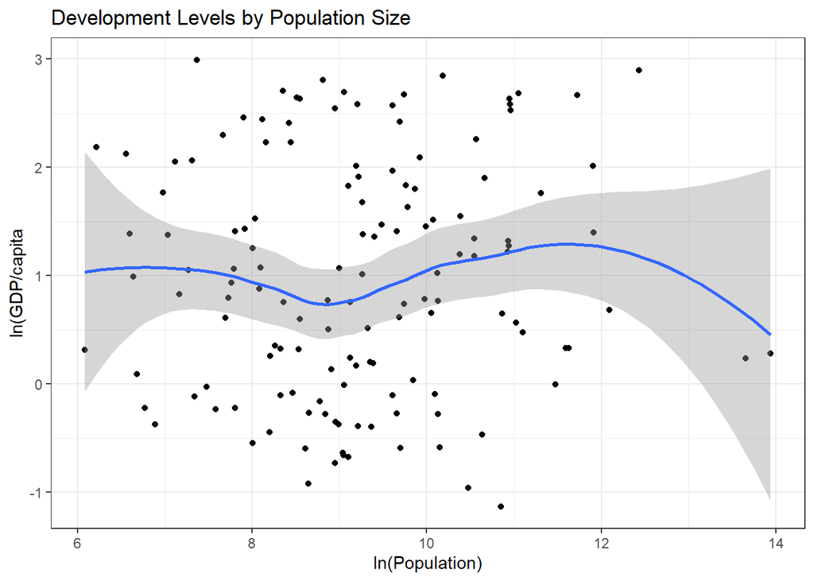

```r
ggplot(wars_1990, aes(x = log_pop, y = log_gdp_cap)) +
  geom_point() +
  labs(x = "ln(Population)", y = "ln(GDP/capita", title = "Development Levels by Population Size") +
  geom_smooth() +
  theme_bw()
```

By separating the outputs like this, it’s easier to comment on what’s happening as well as mentally break up what each stage is doing. This isn’t strictly necessary, but I find it helps clear up the work.

#### Rendering

For the class assignments, you will need to submit both the .qmd file as well as the rendered html output. To create a new Quarto file, go to create a new file in RStudio and select “Quarto Document”. *Make sure* that you have “Use visual markdown editor” unchecked before creating the file.

Rendering will create an html file in the same folder as the .qmd file with the same name (except .html instead of .qmd). This is (one) reason why having good file organization is important. It can often be helpful early on to keep rendering the file as you go to see if any bugs emerge, rather than waiting right up until you need to submit.

### 2. Packages in R

#### a. Load R packages

R has a large number of freely available packages available to install and include in your code. These include code or data that allow you to use material created by others rather than needing to develop it by scratch. If you need to install a package, you can use the function ‘install.packages’ and inside include (as a string, meaning with the quotation marks) the name of the package. For example, in the homework assignment, we will need to use the library ‘wakefield’, so let’s install it now if we haven’t yet:

```r
#install.packages("wakefield")
```

When including a package in a script or qmd file, you use the function ‘library’. If the package is installed, you do not need to include the quotation marks for this. Including a library looks like the following:

```r
library(wakefield)
```

There are many, many useful packages out there. Some of them include:

- tidyverse - this is an umbrella library that includes ggplot and dplyr, which we used extensively in Quant Camp
- haven - this library provides functions to read in data meant for other tools (Stata, SPSS, and SAS)
- stringr - provides a cohesive set of functions designed to make working with strings as easy as possible

**Discussion II**